# **第七章：生态数据的空间分析**

本章内容简介：

- 7.1 目标
- 7.2 空间结构与空间分析简介
- 7.3 多变量趋势面分析(Multivariate Trend-Surface Analysis)
- 7.4 基于特征向量的空间变量与空间模型(Eigenvector-Based Spatial Variables and Spatial Modelling)
- 7.5 另一种空间结构的观察方法: 多尺度排序(Multiscale Ordination, MSO)
- 7.6 多元变量方差分析中的无重复时空交互检验(Space-Time Interaction Test in Multivariate ANOVA, Without Replicates)

## 7.1 目标

生态学数据的空间分析是一个非常复杂且重要的研究板块. 本章仅作为一个入门级别的导引, 为能够了解更多关于空间分析在R中的具体应用方法, 可以参考 [Bivand于2013年的研究成果](https://www.springer.com/gp/book/9781461476177).

- 学习如何计算空间相关性测度并绘制空间相关图
- 学习如何构建来自位点坐标和位点之间联系的空间描述
- 识别, 检验和解释尺度依赖型的空间结构
- 结合空间分析和方差分解
- 通过计算解释性和剩余排序分数的函数来评估典范排序中的空间结构

## 7.2 空间结构与空间分析简介

### 7.2.1 简介

空间分析在生态数据分析中扮演着重要的角色. 有生命体征的群落在多个尺度上都有空间结构, 这些结构是一些过程发生之后的表现(结果). Beta 多样性就是群落组成上的空间差异, 很多研究表明多种因子(比如饮食, 相互作用关系, 生态位的差异性, 物理化学因素, 气候因素等等; 生物因素和非生物因素)可以解释群落组成上的空间差异性. 横向尺度地比较分析, 纵向尺度(比如时间维度)上比较分析.

生态学数据是多种空间和多种非空间结构上的组合:

- 每个响应变量的总体均值(物种);
- *如果整个取样区域受到一个复合的过程影响, 且这个过程影响范围大于取样区, 总体平均会随着梯度发生变化, 导致趋势的存在*
- *区域尺度的空间结构: 如果各种不同的(生物/非生物因素)生态过程对群落的影响发生在比整个取样区域小的尺度上, 将产生可识别的空间结构*
- *局部确定但无法识别的空间结构, 可能是因为取样尺度不够小, 导致无法识别微尺度斑块*
- *随机噪音(误差): 方差的残差(随机)组分. 该部分由每个取样点本身的局部效应引起*

> 空间分析的主要目的是区分上面这些空间结构的来源并进行建模分析.

### 7.2.2 诱导空间依赖与空间自相关(Induced Spatial Dependence and Spatial Autocorrelation)

*响应变量矩阵Y的空间结构可以有两个主要的来源: 由外部(环境)因子控制的空间街哦过和来自响应变量本身的空间结构.* *第一种称之为 诱导性空间依赖, 第二种称之为空间自相关.*

*如果潜在的生物学过程影响范围大于区域区域, 空间自相关也有可能产生梯度假象.*

*目前还没有分辨真假梯度的统计方法, 只能依赖生物学假设去推断: 在某些情况下, 可以假设产生空间相关的生态过程是否也能够产生空间自相关. 在其他情况下, 可以通过比较当前研究区域尺度上的过程与更大区域尺度的过程去分辨真假梯度.*

*空间相关用来度量这样一个事实: 空间接近的两个点之间的值比随机抽取的两个点之间的值更为相似或者相异.* 这种由真正的自相关或者空间依赖引起的空间结构对统计检验有不利的影响.

对于具有空间相关的响应度量, 如果已知样方的位置和生物学过程, 至少在某种程度上可以通过其他样方的值预测目标样方的值. 这种相互关系意味着样方值之间彼此不是随机独立, 这种情况违背了样方独立性的统计检验. (即, 新的样本没有带来新的自由度)

因此在分析具有空间相关的数据时, 参数检验的自由度往往被高估, 导致检验的结果偏向“自由”的一边: 即导致零假设经常被错误地拒绝.

### 7.2.3 空间尺度(Spatial Scale)

在本文中, 尺度包括取样设计和空间分析的几种属性.

取样设计有三个属性属于空间尺度范畴:

- 取样单元大小
- 取样区间(取样间隔)
- 取样程度(取样范围)

取样设计的三个属性会影响可识别和可度量的空间结构的类型和大小. -1> 取样单元整合了发生在取样单元内的空间结构: 导致无法识别等于或者小于取样单元的空间结构; -2> 取样间隔决定能够被识别的最小空间结构; -3> 研究区域的取样程度是可测空间的格局大小的上限. 因此如何正确匹配三个取样设计属性与被验证的假设和被研究系统的特征非常重要.

研究对象的生态背景决定如何最优化取样单元大小,取样间隔和取样范围. 最优化的取样单元大小应与研究对象的单位匹配(如动植物个体, 植被的斑块等等). 取样间隔应于研究对象的平均距离相匹配. 取样范围应尽量包含所有研究生态过程的所有区域.

在生态学研究中, 小尺度是指微小的空间范围, 大尺度是指大的空间范围. 由于这种概念容易与地理学中的尺度产生混淆, 因此该处使用宽尺度(broad scale)和微尺度(fine scale)两种等同的概念.

生态学过程发生在不同的尺度上, 导致复杂的,多尺度的生态格局. 确定格局的生态尺度和寻找与生态格局相关的生态过程是当前生态学研究中的重要目标.

> 因此, 研究人员必须依赖适合的取样设计和强大的分析工具来进行科学研究 – 事半功倍

### 7.2.4 空间异质性(Spatial Heterogeneity)

生态过程或者生态格局在区域间的变化称之为空间异质性. 空间分析中的很多方法斗殴致力于度量空间异质性的强度和广度, 同时检验空间相关是否存在. 空间相关性检验, 不仅可验证“数据中不存在的空间相关”这样的零假设, 同时可以直接获得空间相关信息, 并在概念和统计模型中使用这些信息.

构建结构函数, 是研究与样方间距离有关的空间异质性的常用方法. 县官途, 变异函数图, 周期图等均属于结构函数.

### 7.2.5 空间相关或相关函数与空间相关图(Spatial Correlation or Autocorrelation Functions and Spatial Correlograms)

相关图是空间相关系数沿距离等级的变化图. 相关图结合统计检验可以评估空间相关结构的范围和类型.

一个典型的空间相关系数变化现象: 在很短的距离内为正值, 随着距离增加逐渐下降到负值, 当距离达到某一点则变为不显著; 当距离超过不显著的阈值之后, 所有的样方对之间可以视为空间独立.

空间相关图可以展示任何类型的空间相关(诱导性空间依赖,空间自相关等).

```r
# 解决警告信息的显示问题
# Warning: Input string not available in this locale
Sys.setlocale('LC_ALL','C')
```

```
## [1] "C"
```

```r
# 导入分析包
# ade4 https://www.rdocumentation.org/packages/ade4/versions/1.7-13
# 生态型数据分析(多变量数据分析): 环境科学中的探索分析和 Euclidean 方法
# vegan https://www.rdocumentation.org/packages/vegan/versions/2.4-2
# 群落生态分析包: 排序方法, 多样性分析等
# ape https://www.rdocumentation.org/packages/ape/versions/5.3
# 系统发育与进化分析
# adegraphics https://www.rdocumentation.org/packages/adegraphics/versions/1.0-15
# 表示多变量数据的图形功能,  'ade4' 的重新集成
# adespatial https://www.rdocumentation.org/packages/adespatial/versions/0.3-4
# 多元多尺度空间分析
# spdep 空间依赖性: 加权方案, 统计, 模型
# https://www.rdocumentation.org/packages/spdep/versions/1.1-2
# adegraphics 用于表示多变量数据的图形功能, 它是'ade4'包中可用功能的完全重新实现
# https://www.rdocumentation.org/packages/adegraphics/versions/1.0-15
library(ape)
library(spdep)
library(ade4)
library(adegraphics)
library(adespatial)
library(vegan)
# 导入分析脚本 & 数据集
source("Functions/plot.links.R")
source("Functions/sr.value.R")
source("Functions/quickMEM.R")
source("Functions/scalog.R")
load("Data/mite.RData")

# 数据变换
mite.h <- decostand (mite, "hellinger")
# scale() 对矩阵相似对象进行缩放或者居中
# https://www.rdocumentation.org/packages/base/versions/3.6.0/topics/scale
# 默认 center = T, 减去列平均值然后 centered
mite.xy.c <- scale(mite.xy, center = TRUE, scale = FALSE)
```

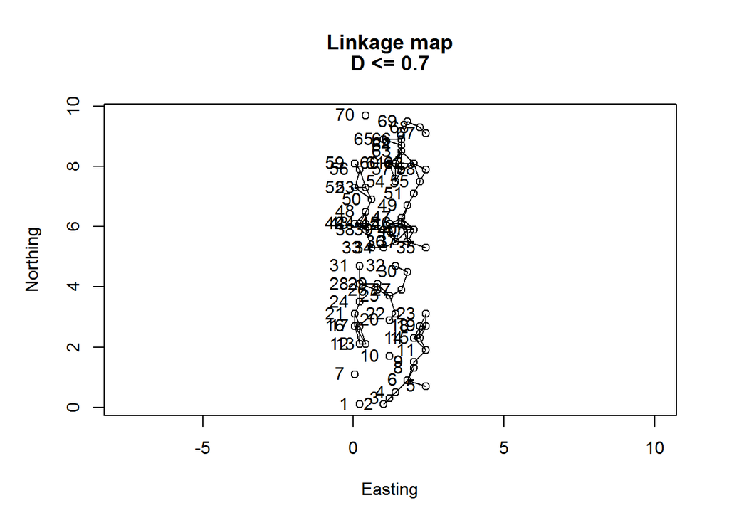

```r
# 单变量空间相关图 - Univariate spatial correlogram (based on Moran's I)
# 绘制PCOA图, 并添加与差异阈值以下的值对应的线条
# https://github.com/JoeyBernhardt/NumericalEcology/blob/master/plot.links.R
plot.links(mite.xy, thresh = 0.7)
```

```r
# https://www.rdocumentation.org/packages/spdep/versions/1.1-2/topics/dnearneigh
# 基于欧式距离(Euclidean distance)确定邻近关系
nb1 <- dnearneigh(as.matrix(mite.xy), 0, 0.7)
summary(nb1)
```

```
## Neighbour list object:
## Number of regions: 70
## Number of nonzero links: 222
## Percentage nonzero weights: 4.530612
## Average number of links: 3.171429
## 4 regions with no links:
## 1 7 10 70
## Link number distribution:
##
##  0  1  2  3  4  5  6  8
##  4  7 14 16 15  7  6  1
## 7 least connected regions:
## 5 20 31 32 35 59 67 with 1 link
## 1 most connected region:
## 46 with 8 links
```

```r
# 基质密度的相关图 - Correlogram of substrate density
# sp.correlogram 空间相关图
# https://www.rdocumentation.org/packages/spdep/versions/1.1-2/topics/sp.correlogram
subs.dens <- mite.env[ ,1]
subs.correlog <-
  sp.correlogram(nb1,
                 subs.dens,
                 order = 14,
                 method = "I",
       zero.policy = TRUE)
print(subs.correlog, p.adj.method = "holm")
```

```
## Spatial correlogram for subs.dens
## method: Moran's I
##           estimate expectation   variance standard deviate Pr(I) two sided
## 1 (66)   0.2835270  -0.0153846  0.0101136           2.9723         0.04138
## 2 (66)  -0.0237187  -0.0153846  0.0105273          -0.0812         1.00000
## 3 (66)  -0.0037775  -0.0153846  0.0102975           0.1144         1.00000
## 4 (66)  -0.2343709  -0.0153846  0.0118947          -2.0079         0.58052
## 5 (64)   0.0899771  -0.0158730  0.0127277           0.9382         1.00000
## 6 (57)   0.1437904  -0.0178571  0.0151816           1.3119         1.00000
## 7 (50)   0.0852128  -0.0204082  0.0161017           0.8324         1.00000
## 8 (44)  -0.0991737  -0.0232558  0.0188426          -0.5531         1.00000
## 9 (39)  -0.1527883  -0.0263158  0.0246495          -0.8055         1.00000
## 10 (33) -0.0552367  -0.0312500  0.0303455          -0.1377         1.00000
## 11 (26)  0.1354649  -0.0400000  0.0396610           0.8811         1.00000
## 12 (20)  0.1274290  -0.0526316  0.0525510           0.7855         1.00000
```

[output cut: 19 more lines]

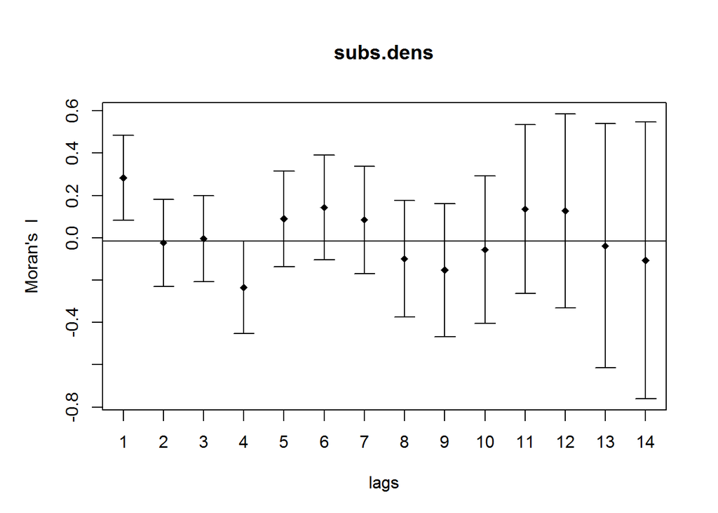

```r
plot(subs.correlog)
```

多变量的空间相关可以通过 Mantel 相关图进行评估和检验, 即计算样方相异矩阵与样方距离等级矩阵的标准化的Mantel相关系数; 样方等级矩阵中, 样方对之间的距离属于设定距离等级时赋予值为 0, 否则赋予 1.

```r
# 螨虫数据集的 Mantel 相关图(correlogram)
# 首先去除物种数据; see Sect. 7.3
mite.h.det <- resid(lm(as.matrix(mite.h) ~ ., data = mite.xy))
mite.h.D1 <- dist(mite.h.det) # 计算距离矩阵
# mantel.correlog 计算多变量 Mantel 相关图
# https://www.rdocumentation.org/packages/vegan/versions/2.4-2/topics/mantel.correlog
(mite.correlog <-
  mantel.correlog(mite.h.D1,
                  XY = mite.xy,
                  nperm = 999))
```

```
##
## Mantel Correlogram Analysis
##
## Call:
##
## mantel.correlog(D.eco = mite.h.D1, XY = mite.xy, nperm = 999)
##
##         class.index     n.dist Mantel.cor Pr(Mantel) Pr(corrected)
## D.cl.1     0.514182 358.000000   0.135713      0.001         0.001 ***
## D.cl.2     1.242546 650.000000   0.118174      0.001         0.002 **
## D.cl.3     1.970910 796.000000   0.037820      0.047         0.047 *
## D.cl.4     2.699274 696.000000  -0.098605      0.001         0.004 **
## D.cl.5     3.427638 500.000000  -0.112682      0.001         0.005 **
## D.cl.6     4.156002 468.000000  -0.107603      0.001         0.006 **
## D.cl.7     4.884366 364.000000  -0.022264      0.137         0.137
## D.cl.8     5.612730 326.000000         NA         NA            NA
## D.cl.9     6.341094 260.000000         NA         NA            NA
## D.cl.10    7.069458 184.000000         NA         NA            NA
## D.cl.11    7.797822 130.000000         NA         NA            NA
## D.cl.12    8.526186  66.000000         NA         NA            NA
## D.cl.13    9.254550  32.000000         NA         NA            NA
## ---
## Signif. codes:  0 '***' 0.001 '**' 0.01 '*' 0.05 '.' 0.1 ' ' 1
```

```r
summary(mite.correlog)
```

```
##            Length Class  Mode
## mantel.res 65     -none- numeric
## n.class     1     -none- numeric
## break.pts  14     -none- numeric
## mult        1     -none- character
## n.tests     1     -none- numeric
## call        4     -none- call
```

```r
# 分类的数量
mite.correlog$n.class # or: mite.correlog[2]
```

```
## [1] 13
```

```r
# 断点 - Break points
mite.correlog$break.pts # or: mite.correlog[3]
```

```
##  [1] 0.150000 0.878364 1.606728 2.335092 3.063456 3.791820 4.520184
##  [8] 5.248548 5.976912 6.705276 7.433640 8.162004 8.890368 9.618732
```

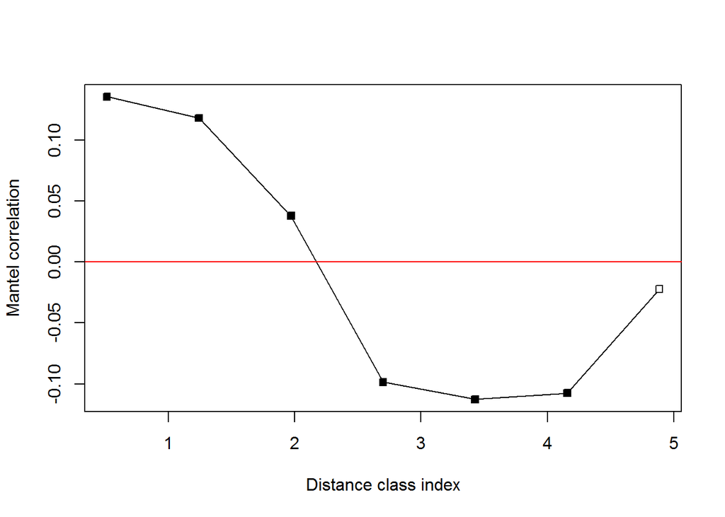

```r
# 绘制 Mantel 相关图(correlogram)
plot(mite.correlog)
```

### 7.2.6 空间相关性存在的检验: 条件(Testing for the Presence of Spatial Correlation: Conditions)

空间相关系数可以检验显著性, 但必须符合相关性分析的条件. 如果采用置换检验, 数据的正态性要求可放宽. 为检验空间相关系数的显著性, 还必须符合“二阶稳定”的要求.

二阶稳定, 是指变量的平均值和空间协方差在整个研究区域不变, 且方差是有限. 换句话, 即使用相同的空间相关函数足以描述研究区域所有部分的空间变化.

对于存在明显趋势的数据(即, 真梯度), 空间相关系数显著性无法检验. 对于从一个空间结构明显不同的区域获得的变量, 应使用不同的空间相关系数建模.

单一趋势的数据通常可以通过样方地理坐标的一阶或者高阶函数实现去趋势.

二阶稳定的放宽模式(也称为内在假设), 是指在整个研究区域所有距离为 d 的两点差值的平均值为 0 且存在不变和有限的方差.

如果具备这些条件可以计算和查看相关图, 但不能检验空间相关系数的显著性.

### 7.2.7 空间结构建模(Modelling Spatial Structures)

建模导向也是空间分析的一种. 模拟的空间结构可以被假设与解释变量有关, 也可以帮助产生这样的新假设: 究竟哪些过程这样的空间结构.

任何尺度多有可能存在空间结构. **识别不同尺度和分别模拟对应的空间结构是生态学家长期追求的目标**.

趋势面分析只能提取非常简单的空间结构, 因为原始的多项式非常复杂且高度相关, 在实际应用中一般只限用到三阶多项式. 邻体矩阵主坐标分析(PCNM)和其他基于特征根的空间函数是空间分析方法的突破.

## 7.3 多变量趋势面分析(Multivariate Trend-Surface Analysis)

### 7.3.1 简介

简单回归仅能模拟线性趋势, 线性趋势可以通过样带收集的数据与X坐标的回归进行拟合, 而平面趋势也可以通过相同的方法进行拟合.

一种常用的曲线结构的建模方式是增加坐标变量的多项式作为解释变量. 二阶和三阶项都是常用的多项式.

通过 RDA 或者 CCA 可以将趋势面分析用于多元数据分析, 分析的结果是一组独立的空间模型(每个典型轴代表一个模型), 可以使用前向选择保留只含有显著成分的模型.

### 7.3.2 趋势面分析的实际应用(In practice)

趋势面分析最重要的应用是去趋势. 一般先检验数据的空间线性趋势, 如果趋势显著, 对数据进行去趋势处理, 即使用 X_Y 坐标对变量进行回归分析, 保留残差, 使用 lm() 函数可以很容易的获取回归的残差.

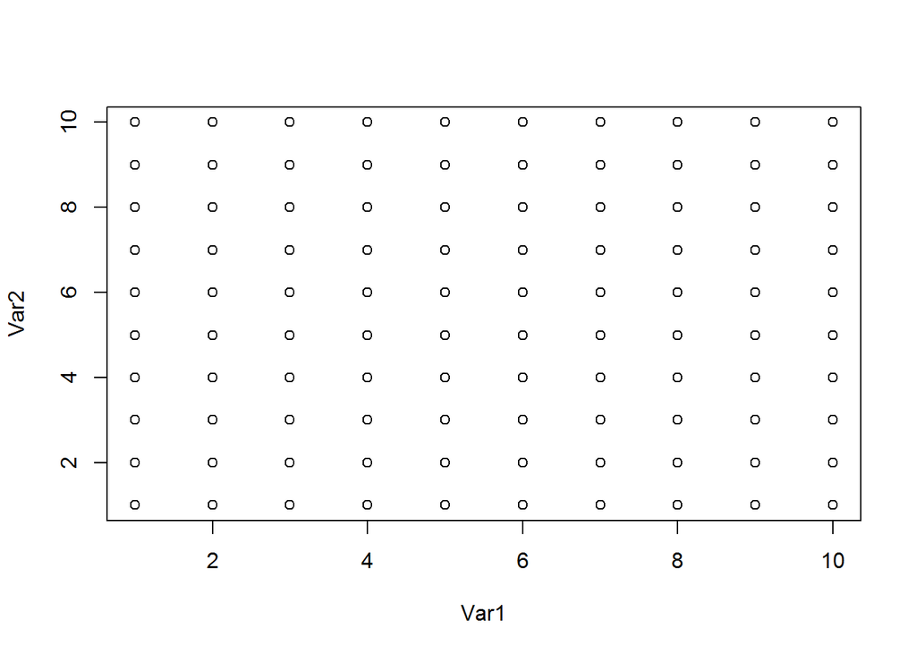

```r
# 简单模型 - 方形 & 定期采样表面 Simple models on a square, regularly sampled surface
# https://www.rdocumentation.org/packages/base/versions/3.6.0/topics/expand.grid
# expand.grid - 从因子变量的所有组合创建数据框
xygrid <- expand.grid(1:10, 1:10)
plot(xygrid)
```

```r
# 质心化 - 中心化处理矩阵(数据框)数据 - Centring
# scale() 对矩阵相似对象进行缩放或者居中
# https://www.rdocumentation.org/packages/base/versions/3.6.0/topics/scale
# 默认 center = T, 减去列平均值然后 centered
# center = F, 减去列平均值
(xygrid.c <- scale(xygrid, scale = FALSE))
```

```
##        Var1 Var2
##   [1,] -4.5 -4.5
##   [2,] -3.5 -4.5
##   [3,] -2.5 -4.5
##   [4,] -1.5 -4.5
##   [5,] -0.5 -4.5
##   [6,]  0.5 -4.5
##   [7,]  1.5 -4.5
##   [8,]  2.5 -4.5
##   [9,]  3.5 -4.5
##  [10,]  4.5 -4.5
##  [11,] -4.5 -3.5
##  [12,] -3.5 -3.5
##  [13,] -2.5 -3.5
##  [14,] -1.5 -3.5
```

[output cut: 89 more lines]

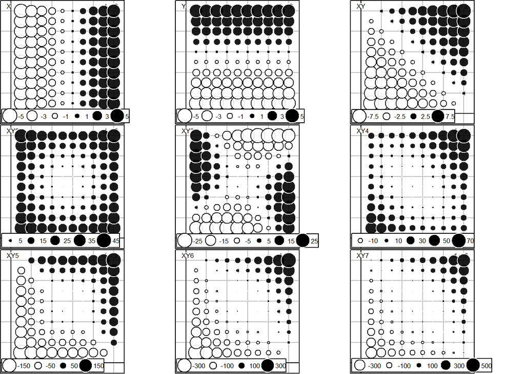

```r
X <- xygrid.c[ ,1]
Y <- xygrid.c[ ,2]
XY <- X + Y
XY2 <- X ^ 2  +  Y ^ 2
XY3 <- X ^ 2 - X * Y - Y ^ 2
XY4 <- X + Y  +  X ^ 2  +  X * Y  +  Y ^ 2
XY5 <- X ^ 3  +  Y ^ 3
XY6 <- X ^ 3  +  X ^ 2 * Y  +  X * Y ^ 2  +  Y ^ 3
XY7 <- X  +  Y  +  X ^ 2  +  X * Y  +  Y ^ 2  +  X ^ 3 +  X ^ 2 * Y  +  X * Y ^ 2  +  Y ^ 3
xy3deg <- cbind(X, Y, XY, XY2, XY3, XY4, XY5, XY6, XY7)

# 散点图来表示变量值
s.value(xygrid, xy3deg, symbol = "circle")
```

```r
## --- 对螨虫数据集进行趋势面分析 ---
# 先前居中的X-Y坐标上 计算原始(非正交)三次多项式函数 - on the previously centred X-Y coordinates
mite.poly <- poly(as.matrix(mite.xy.c),
                  degree = 3,
                  raw = TRUE)
colnames(mite.poly) <-
    c("X", "X2", "X3", "Y", "XY", "X2Y", "Y2", "XY2", "Y3")

# 对所有 9 个多项式进行冗余分析
(mite.trend.rda <- rda(mite.h ~ .,
                       data = as.data.frame(mite.poly)))
```

```
## Call: rda(formula = mite.h ~ X + X2 + X3 + Y + XY + X2Y + Y2 + XY2
## + Y3, data = as.data.frame(mite.poly))
##
##               Inertia Proportion Rank
## Total          0.3943     1.0000
## Constrained    0.2026     0.5139    9
## Unconstrained  0.1916     0.4861   35
## Inertia is variance
##
## Eigenvalues for constrained axes:
##    RDA1    RDA2    RDA3    RDA4    RDA5    RDA6    RDA7    RDA8    RDA9
## 0.14336 0.02546 0.01727 0.00618 0.00301 0.00291 0.00219 0.00140 0.00085
##
## Eigenvalues for unconstrained axes:
##     PC1     PC2     PC3     PC4     PC5     PC6     PC7     PC8
## 0.04471 0.02738 0.01947 0.01257 0.01173 0.01086 0.00784 0.00701
## (Showing 8 of 35 unconstrained eigenvalues)
```

```r
# 计算调整的 R方
# https://www.rdocumentation.org/packages/vegan/versions/2.4-2/topics/RsquareAdj
(R2adj.poly <- RsquareAdj(mite.trend.rda)$adj.r.squared)
```

```
## [1] 0.4410071
```

```r
# 使用 地理坐标的三项正交多项式 进行冗余分析
# RDA using a third-degree orthogonal polynomial of the geographic coordinates
mite.poly.ortho <- poly(as.matrix(mite.xy),
                        degree = 3)
colnames(mite.poly.ortho) <-
    c("X", "X2", "X3", "Y", "XY", "X2Y", "Y2", "XY2", "Y3")
(mite.trend.rda.ortho <-
  rda(mite.h ~ .,
      data = as.data.frame(mite.poly.ortho)))
```

```
## Call: rda(formula = mite.h ~ X + X2 + X3 + Y + XY + X2Y + Y2 + XY2
## + Y3, data = as.data.frame(mite.poly.ortho))
##
##               Inertia Proportion Rank
## Total          0.3943     1.0000
## Constrained    0.2026     0.5139    9
## Unconstrained  0.1916     0.4861   35
## Inertia is variance
##
## Eigenvalues for constrained axes:
##    RDA1    RDA2    RDA3    RDA4    RDA5    RDA6    RDA7    RDA8    RDA9
## 0.14336 0.02546 0.01727 0.00618 0.00301 0.00291 0.00219 0.00140 0.00085
##
## Eigenvalues for unconstrained axes:
##     PC1     PC2     PC3     PC4     PC5     PC6     PC7     PC8
## 0.04471 0.02738 0.01947 0.01257 0.01173 0.01086 0.00784 0.00701
## (Showing 8 of 35 unconstrained eigenvalues)
```

```r
# 计算调整的 R方
# https://www.rdocumentation.org/packages/vegan/versions/2.4-2/topics/RsquareAdj
(R2adj.poly2 <- RsquareAdj(mite.trend.rda.ortho)$adj.r.squared)
```

```
## [1] 0.4410071
```

```r
# 前向选择 - Forward selection using Blanchet et al. (2008a)
# 双停准则 - double stopping criterion
# https://www.rdocumentation.org/packages/adespatial/versions/0.3-4/topics/forward.sel
# 在简化模型下使用置换进行多元变量数据集的正向选择
# Forward Selection With Multivariate Y Using Permutation Under Reducel Model
(mite.trend.fwd <-
  forward.sel(mite.h, mite.poly.ortho, adjR2thresh = R2adj.poly2))
```

```
## Testing variable 1
## Testing variable 2
## Testing variable 3
## Testing variable 4
## Testing variable 5
## Testing variable 6
## Testing variable 7
## Procedure stopped (adjR2thresh criteria) adjR2cum = 0.441747 with 7 variables (> 0.441007)
```

```
##   variables order         R2     R2Cum  AdjR2Cum         F pvalue
## 1         Y     4 0.26688569 0.2668857 0.2561046 24.754975  0.001
## 2        Y3     9 0.11826011 0.3851458 0.3667919 12.886676  0.001
## 3        Y2     7 0.04310604 0.4282518 0.4022633  4.975964  0.001
## 4        XY     5 0.01916996 0.4474218 0.4134170  2.254971  0.018
## 5       X2Y     6 0.01957416 0.4669960 0.4253550  2.350350  0.014
## 6         X     1 0.01931519 0.4863111 0.4373884  2.368860  0.013
```

```r
(mite.trend.rda2 <- rda(mite.h ~ .,
          data = as.data.frame(mite.poly)[ ,mite.trend.fwd[ ,2]]))
```

```
## Call: rda(formula = mite.h ~ Y + Y3 + Y2 + XY + X2Y + X, data =
## as.data.frame(mite.poly)[, mite.trend.fwd[, 2]])
##
##               Inertia Proportion Rank
## Total          0.3943     1.0000
## Constrained    0.1917     0.4863    6
## Unconstrained  0.2025     0.5137   35
## Inertia is variance
##
## Eigenvalues for constrained axes:
##    RDA1    RDA2    RDA3    RDA4    RDA5    RDA6
## 0.14140 0.02320 0.01620 0.00584 0.00277 0.00234
##
## Eigenvalues for unconstrained axes:
##     PC1     PC2     PC3     PC4     PC5     PC6     PC7     PC8
## 0.04845 0.02764 0.02000 0.01311 0.01195 0.01152 0.00816 0.00784
## (Showing 8 of 35 unconstrained eigenvalues)
```

```r
# 全部检验
anova(mite.trend.rda2)
```

```
## Permutation test for rda under reduced model
## Permutation: free
## Number of permutations: 999
##
## Model: rda(formula = mite.h ~ Y + Y3 + Y2 + XY + X2Y + X, data = as.data.frame(mite.poly)[, mite.trend.fwd[, 2]])
##          Df Variance      F Pr(>F)
## Model     6  0.19174 9.9404  0.001 ***
## Residual 63  0.20253
## ---
## Signif. codes:  0 '***' 0.001 '**' 0.01 '*' 0.05 '.' 0.1 ' ' 1
```

```r
# 检验所有典范轴 - canonic axis
anova(mite.trend.rda2, by = "axis")
```

```
## Permutation test for rda under reduced model
## Forward tests for axes
## Permutation: free
## Number of permutations: 999
##
## Model: rda(formula = mite.h ~ Y + Y3 + Y2 + XY + X2Y + X, data = as.data.frame(mite.poly)[, mite.trend.fwd[, 2]])
##          Df Variance       F Pr(>F)
## RDA1      1 0.141401 43.9839  0.001 ***
## RDA2      1 0.023197  7.2155  0.002 **
## RDA3      1 0.016198  5.0386  0.002 **
## RDA4      1 0.005840  1.8166  0.302
## RDA5      1 0.002768  0.8609  0.871
## RDA6      1 0.002337  0.7269  0.683
## Residual 63 0.202535
## ---
## Signif. codes:  0 '***' 0.001 '**' 0.01 '*' 0.05 '.' 0.1 ' ' 1
```

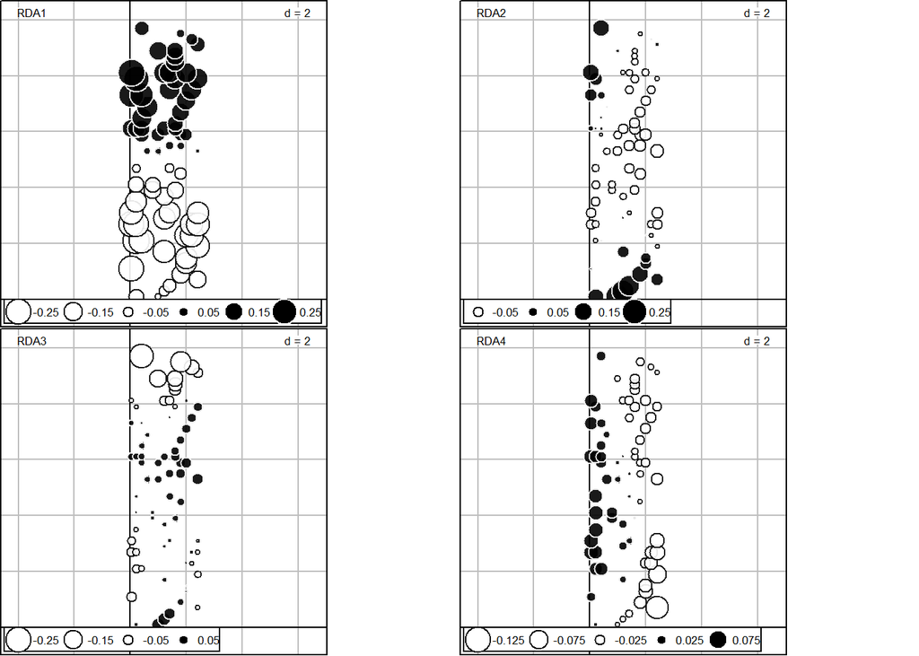

```r
# 质心化 - 中心化处理矩阵(数据框)数据 - Centring
# scale() 对矩阵相似对象进行缩放或者居中
# https://www.rdocumentation.org/packages/base/versions/3.6.0/topics/scale
# 默认 center = T, 减去列平均值然后 centered
# center = F, 减去列平均值
mite.trend.fit <-
  scores(mite.trend.rda2,
         choices = 1:4,
         display = "lc",
         scaling = 1)
# 散点图来表示变量值
s.value(mite.xy, mite.trend.fit, symbol = "circle")
```

## 7.4 基于特征向量的空间变量与空间模型(Eigenvector-Based Spatial Variables and Spatial Modelling)

### 7.4.1 简介

趋势面分析是一种非常粗放的空间建模方法. 生态过程和生态数据的多尺度属性需要寻求在所有尺度上都能够对空间结构进行识别和建模. 换言之, 需要在宽尺度(整个取样区域)至微尺度(取样间隔的倍数)都能够对空间结构进行建模.

为能在典范排序中实现, 必须构建能够模拟所有尺度的空间结构的变量. 邻体矩阵主坐标分析(principal coordinates of neighbour matrices, PCNM)衍生出.

> PCNM 目前多被称为 distance-based MEM, or dbMEM. Moran’s Eigenvector map

### 7.4.2 基于距离的 Moran 特征向量图(Distance-Based Moran’s Eigenvector Maps, dbMEM) 和 相邻矩阵主坐标分析(Principal Coordinates of Neighbour Matrices, PCNM)

#### 7.4.2.1 引言

PCNM 计算步骤:

- 构建样方之间的欧式(地理)距离矩阵;
- 消减距离矩阵规模, 只保留一定规模的邻体之间的距离;
- 计算消减距离矩阵的主坐标分析(PCoA);
- 在大部分研究中, 保留具有正空间相关(Moran指数 大于 E)的特征向量;
- 使用保留的特征向量作为空间解释向量, 与响应变量进行多元回归或 RDA 分析;

PCNM 可以获得很多比取样间隔更宽尺度的正交(线性独立)空间变量; 其次, 通过大量的数据模拟演示, PCNM 可以对任何类型的空间结构进行建模.

PCNM 可以用于任何取样设计. 规则取样的空间变量更容易解读, 如果是不规则的取样设计, 为了保证所有点都能被连接, 阈值有时会比较大. 大的阈值, 意味着微空间结构的丢失; 因此, 对于不规则取样, 理想的阈值应在保证所有点都能连接的条件下选择尽可能小的距离.

在保证满足所有点都能被连接的而要求下, 如果选择到的阈值很大, -1> 增加有限的虚拟补充点去减少阈值距离, -2> 计算 PCNM 变量, -3> 从 PCNM 变量矩阵中剔除虚拟补充点. 添加虚拟补充点的措施可以使小的空间结构得以展示, 但会导致 PCNM 的变量不再相互正交. 如果添加的补充点比例很小, 偏离正交性的程度不会太明显.

传统的 PCNM 中, 所有正特征根都具有特征函数.

在标准的MEM分析内, Moran指数是特征根的线性函数, 但在PCNM分析中特征根与空间相关系数并没有简单的关系. 因此, 在所有的PCNM分析中, 最好及时计算 Moran指数 (PCNM() 可自动计算 Moran指数).

#### 7.4.2.2 常规采样设计的 dbMEM 变量 (Regular Sampling Designs)

```r
# 1. 一维采样
# One-dimensional sampling: 具有100个等间距点的横断面 - transect with 100 equispaced points.
# 相邻点之间的距离是 1.
# dbmem() 自动计算阈值

# 生成样点带 - Generate transect points
tr100 <- 1 : 100

# 创建 dbMEM 本征函数(eigenfunctions) with Moran's I 对应空间正相关(positive spatial correlation):
# 参数MEM.autocor = "positive" 默认
# https://www.rdocumentation.org/packages/adespatial/versions/0.3-4/topics/dbmem
# 空间本征函数
tr100.dbmem.tmp <- dbmem(tr100,
                         silent = FALSE) # 是否显示计算过程
```

```
## Truncation level = 1.000001
## Time to compute dbMEMs = 0.010000  sec
```

```r
tr100.dbmem <- as.data.frame(tr100.dbmem.tmp)
# 展示特征值 - eigenvalues
attributes(tr100.dbmem.tmp)$values
```

```
##  [1] 0.0187137299 0.0186758208 0.0186050601 0.0185310247 0.0184244109
##  [6] 0.0183145782 0.0181724812 0.0180272963 0.0178502458 0.0176702865
## [11] 0.0174589512 0.0172449290 0.0170001113 0.0167528689 0.0164755013
## [16] 0.0161960096 0.0158871507 0.0155765056 0.0152373359 0.0148967533
## [21] 0.0145285708 0.0141593827 0.0137635974 0.0133672465 0.0129453754
## [26] 0.0125234093 0.0120770702 0.0116311356 0.0111620412 0.0106938776
## [31] 0.0102038284 0.0097152614 0.0092061390 0.0086990728 0.0081728328
## [36] 0.0076492435 0.0071079076 0.0065698350 0.0060154832 0.0054650233
## [41] 0.0048997861 0.0043390828 0.0037651326 0.0031963693 0.0026159126
## [46] 0.0020413040 0.0014565721 0.0008783555 0.0002915965
```

```r
# 统计正相关特征值的数量
length(attributes(tr100.dbmem.tmp)$values)
```

```
## [1] 49
```

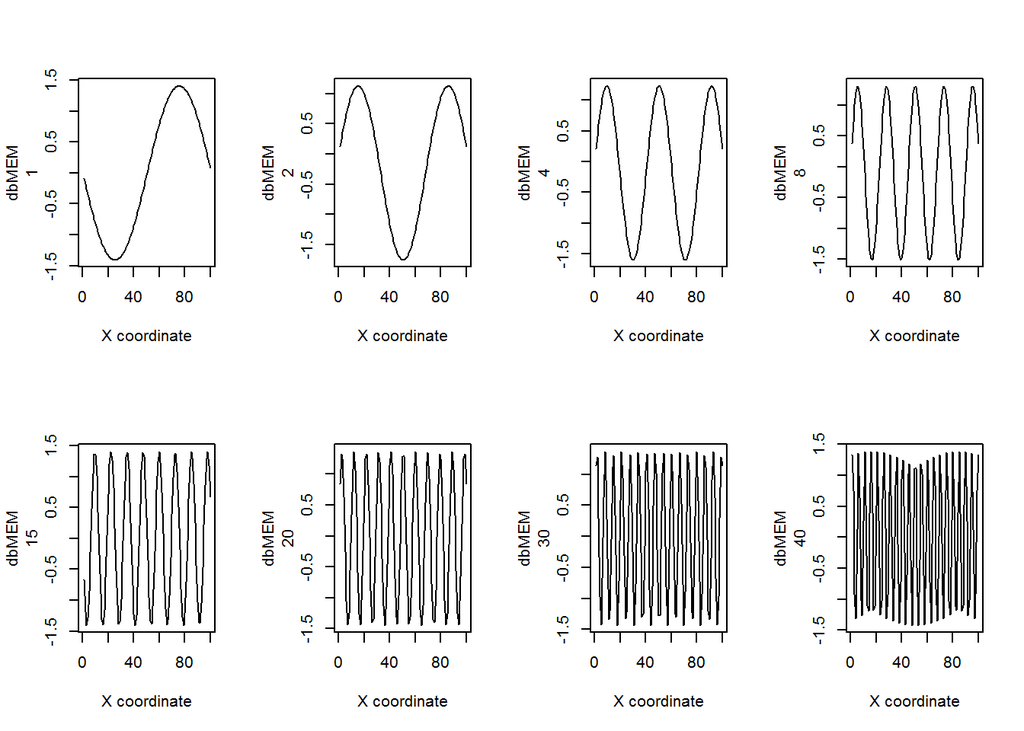

```r
# 绘制一些 dbMEM 变量 modelling 空间正相关(positive spatial correlation) along a transect (Fig. 7.3).
par(mfrow = c(2, 4))
somedbmem <- c(1, 2, 4, 8, 15, 20, 30, 40)
for(i in 1:length(somedbmem)) {
  plot(tr100.dbmem[ ,somedbmem[i]],
       type = "l",
       xlab = "X coordinate",
       ylab = c("dbMEM", somedbmem[i]))
  }
```

```r
# 2. 二维采样
# Two-dimensional sampling: 等间距点的网格, 点之间的最小距离等于1
# grid of equispaced points with smallest distance between points equal to 1 (Fig. 7.4).

# 生成网格点坐标 - Generate grid point coordinates
# https://www.rdocumentation.org/packages/base/versions/3.6.0/topics/expand.grid
# expand.grid - 从因子变量的所有组合创建数据框
xygrid2 <- expand.grid(1:20, 1:20)

# 创建 dbMEM 本征函数(eigenfunctions) with Moran's I
# https://www.rdocumentation.org/packages/adespatial/versions/0.3-4/topics/dbmem
# 空间本征函数
xygrid2.dbmem.tmp <- dbmem(xygrid2)
```

```
## Information: Square regular grid; multiple eigenvalues
```

```r
xygrid2.dbmem <- as.data.frame(xygrid2.dbmem.tmp)
# 计数特征值数量
length(attributes(xygrid2.dbmem.tmp)$values)
```

```
## [1] 189
```

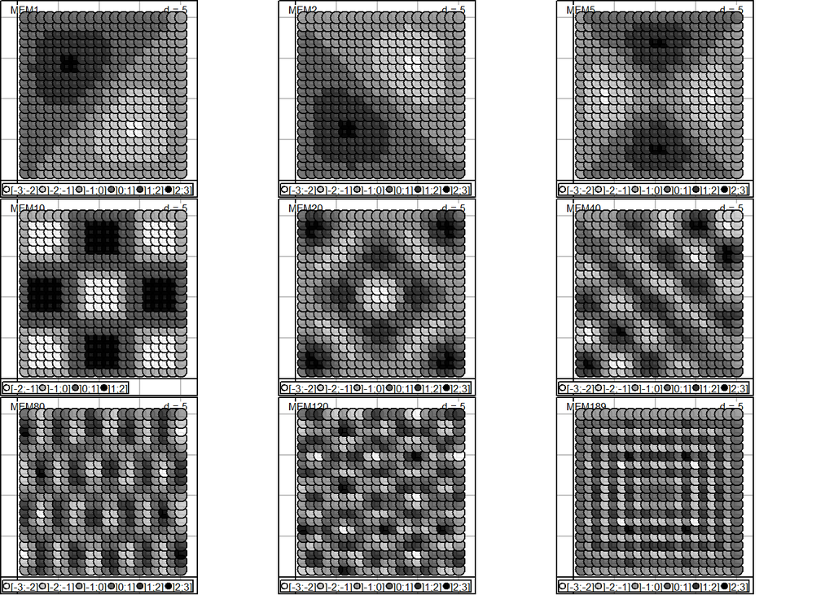

```r
somedbmem2 <- c(1, 2, 5, 10, 20, 40, 80, 120, 189)
# 散点图来表示变量值
s.value(xygrid2, xygrid2.dbmem[ ,somedbmem2],
  method = "color",
  symbol = "circle",
  ppoints.cex = 0.5
  )
```